# World cup analysis

Anders Dahl Boch

2022-12-09

#loading packages and setting up knitr

#read csv For my data i am using The Fjelstul World Cup Database which i found at https://github.com/jfjelstul/worldcup i am only going to use the data sets for goals and Team_appearances and have deleted the other datasets to make it more tidy.

I am first going to start by reading the data set and checking if everything is correct

```r
team_data <- read_csv("data-csv/team_appearances.csv")
goal_data <- read_csv("data-csv/goals.csv")
```

#Check data

```r
head(team_data)
```

```
## # A tibble: 6 × 36
##   key_id tourn…¹ tourn…² match…³ match…⁴ stage…⁵ group…⁶ group…⁷ knock…⁸ repla…⁹
##    <dbl> <chr>   <chr>   <chr>   <chr>   <chr>   <chr>     <dbl>   <dbl>   <dbl>
## 1      1 WC-1930 1930 F… M-1930… France… group … Group 1       1       0       0
## 2      2 WC-1930 1930 F… M-1930… France… group … Group 1       1       0       0
## 3      3 WC-1930 1930 F… M-1930… United… group … Group 4       1       0       0
## 4      4 WC-1930 1930 F… M-1930… United… group … Group 4       1       0       0
## 5      5 WC-1930 1930 F… M-1930… Yugosl… group … Group 2       1       0       0
## 6      6 WC-1930 1930 F… M-1930… Yugosl… group … Group 2       1       0       0
## # … with 26 more variables: replay <dbl>, match_date <date>, match_time <time>,
## #   stadium_id <chr>, stadium_name <chr>, city_name <chr>, country_name <chr>,
## #   team_id <chr>, team_name <chr>, team_code <chr>, opponent_id <chr>,
## #   opponent_name <chr>, opponent_code <chr>, home_team <dbl>, away_team <dbl>,
## #   goals_for <dbl>, goals_against <dbl>, goal_differential <dbl>,
## #   extra_time <dbl>, penalty_shootout <dbl>, penalties_for <dbl>,
## #   penalties_against <dbl>, result <chr>, win <dbl>, lose <dbl>, draw <dbl>, …
```

```r
head(goal_data)
```

```
## # A tibble: 6 × 27
##   key_id goal_id tournament…¹ tourn…² match…³ match…⁴ match_date stage…⁵ group…⁶
##    <dbl> <chr>   <chr>        <chr>   <chr>   <chr>   <date>     <chr>   <chr>
## 1      1 G-0001  WC-1930      1930 F… M-1930… France… 1930-07-13 group … Group 1
## 2      2 G-0002  WC-1930      1930 F… M-1930… France… 1930-07-13 group … Group 1
## 3      3 G-0003  WC-1930      1930 F… M-1930… France… 1930-07-13 group … Group 1
## 4      4 G-0004  WC-1930      1930 F… M-1930… France… 1930-07-13 group … Group 1
## 5      5 G-0005  WC-1930      1930 F… M-1930… France… 1930-07-13 group … Group 1
## 6      6 G-0006  WC-1930      1930 F… M-1930… United… 1930-07-13 group … Group 4
## # … with 18 more variables: team_id <chr>, team_name <chr>, team_code <chr>,
## #   home_team <dbl>, away_team <dbl>, player_id <chr>, family_name <chr>,
## #   given_name <chr>, shirt_number <dbl>, player_team_id <chr>,
## #   player_team_name <chr>, player_team_code <chr>, minute_label <chr>,
## #   minute_regulation <dbl>, minute_stoppage <dbl>, match_period <chr>,
## #   own_goal <dbl>, penalty <dbl>, and abbreviated variable names
## #   ¹tournament_id, ²tournament_name, ³match_id, ⁴match_name, ⁵stage_name, …
```

All of the data looks good, and i can now begin to start to work with and visualize the data

#Manipulating Visualisation and analysing I will be looking at 4 thing: 1.When in a match the most goals are score. 2.Which nations play matches with the highest and lowest scoring games. 3.The development of goals scored over time. 4. the potential in comparing countries

I wil comment on how and why manipulate, visualize and analyze the data as i go trough. The main part of my information/tools came form the below mentioned sites

#visualising: https://datacarpentry.org/R-ecology-lesson/04-visualization-ggplot2.html https://r4ds.had.co.nz/data-visualisation.html

#manipulating: https://r4ds.had.co.nz/wrangle-intro.html https://datacarpentry.org/R-ecology-lesson/03-dplyr.html

#1.Scoring minutes

```r
most_common_scoring_minutes <- goal_data %>%
  group_by(minute_regulation) %>%
  count() %>%
  arrange(desc(n))

most_common_scoring_minutes
```

```
## # A tibble: 116 × 2
## # Groups:   minute_regulation [116]
##    minute_regulation     n
##                <dbl> <int>
##  1                90    94
##  2                75    46
##  3                45    45
##  4                18    44
##  5                73    40
##  6                88    40
##  7                89    38
##  8                83    37
##  9                50    36
## 10                55    36
## # … with 106 more rows
```

The amount of goals in the 90th minute seems unreasonably large. That because all stoppage time goals are counted as goals in the 90th minute. This can partially be fixed by filtering out all goals scored in stoppage time.

However, the dataset does not seem to account for stoppage time before the 1990 World Cup, and therefore the amount of goals being scored in the 90th minute should still be seen as somewhat inflated. The same problem technically applies for the 45th minute, but there is usually less stoppage time in the first half of a football match, and therefore the number of goals scored in the 45th minute should be more reliable.

#Finding non stoppage time goals I am now going to filter out the stoppage time goals

```r
#I want to find the total amount of goals without stoppage time goals
total_goals_without_stoppage <- goal_data %>%
  filter(match_period != c("first half, stoppage time", "second half, stoppage time")) %>%
  summarize(total_goals_without_stoppage = sum(home_team+away_team))

total_goals_without_stoppage
```

```
## # A tibble: 1 × 1
##   total_goals_without_stoppage
##                          <dbl>
## 1                         2499
```

#goals per 1 min interval i want to filter out every stoppage time goal and look at how many percent goals are scored by each minute, i am here going to use the number of non stoppage time goals i found, which i have written in manualy.

I often like to include a print when i am plotting so i can easily see the specific values.

```r
#filter data
most_common_scoring_minutes_filtered <- goal_data %>%
  filter(match_period != c("first half, stoppage time", "second half, stoppage time")) %>%
  group_by(minute_regulation) %>%
  count() %>%
  arrange(desc(n)) %>%
  mutate(percent_goals = (n / 2499) * 100)

#Print
print(most_common_scoring_minutes_filtered)
```

```
## # A tibble: 116 × 3
## # Groups:   minute_regulation [116]
##    minute_regulation     n percent_goals
##                <dbl> <int>         <dbl>
##  1                90    60          2.40
##  2                75    46          1.84
##  3                18    44          1.76
##  4                73    40          1.60
##  5                88    40          1.60
##  6                89    38          1.52
##  7                83    37          1.48
##  8                50    36          1.44
##  9                55    36          1.44
## 10                81    36          1.44
## # … with 106 more rows
```

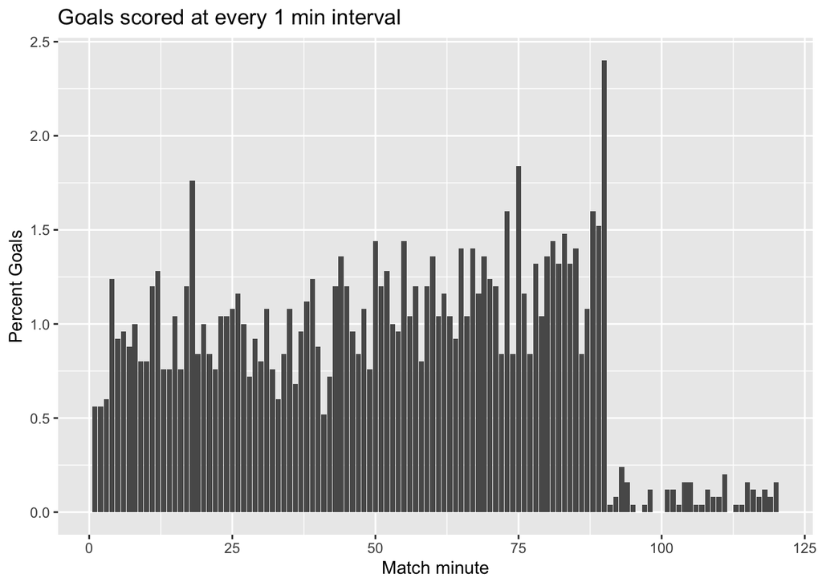

```r
# Visualize the results
ggplot(most_common_scoring_minutes_filtered, aes(x = minute_regulation, y = percent_goals)) +
  geom_bar(stat = "identity") +
  ylab("Percent Goals") +
  xlab("Match minute") +
  ggtitle("Goals scored at every 1 min interval")
```

the plot illustrates the percentage of goals scored at every minute

its a bit hard to read any patterns of intensity of goals scoring from a 1 minute intervals, so i want to look at 10 min intervals instead

#10 min intervals i created a new data frame called minute_regulation_interval, which contains the minute_regulation values grouped into intervals of 10 minutes each. And used The cut() function to create the intervals

```r
# Group minute_regulation into 10 minute intervals
goal_data$minute_regulation_interval <- cut(goal_data$minute_regulation, breaks = seq(0, 90, by = 10),labels = c("0-10", "11-20", "21-30", "31-40", "41-50", "51-60", "61-70", "71-80", "81-90"))

# Find the number of goals scored in each interval
goals_by_interval <- goal_data %>%
  group_by(minute_regulation_interval) %>%
  count() %>%
  rename(goals = n)

#goals scored in each interval
goals_by_interval <- goals_by_interval %>%
  mutate(percent_goals = (goals / 2499) * 100)

print(goals_by_interval)
```

```
## # A tibble: 10 × 3
## # Groups:   minute_regulation_interval [10]
##    minute_regulation_interval goals percent_goals
##    <fct>                      <int>         <dbl>
##  1 0-10                         208          8.32
##  2 11-20                        265         10.6
##  3 21-30                        234          9.36
##  4 31-40                        231          9.24
##  5 41-50                        267         10.7
##  6 51-60                        287         11.5
##  7 61-70                        294         11.8
##  8 71-80                        301         12.0
##  9 81-90                        394         15.8
## 10 <NA>                          67          2.68
```

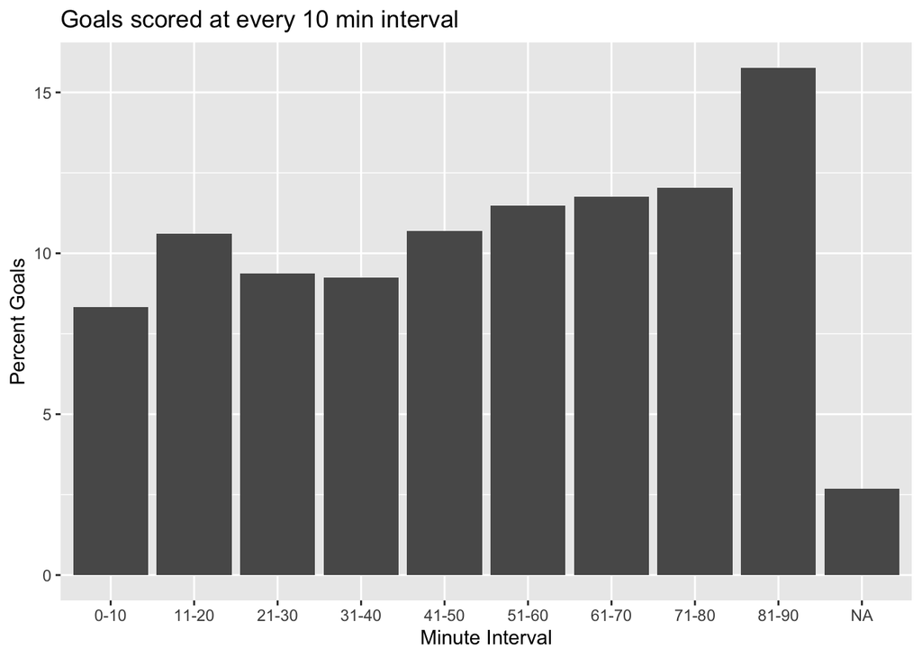

```r
# Visualize the results
ggplot(goals_by_interval, aes(x = minute_regulation_interval, y = percent_goals)) +
  geom_bar(stat = "identity") +
  ylab("Percent Goals") +
  xlab("Minute Interval") +
  ggtitle("Goals scored at every 10 min interval")
```

it can then be concluded the period of the game where the most goals are scored is the late part of the second half.

#2.Average goals per match for nation In the next part i want to find out which Nations play matches with highest an lowest goal averages. which means i will fist have to calculate the number of matches

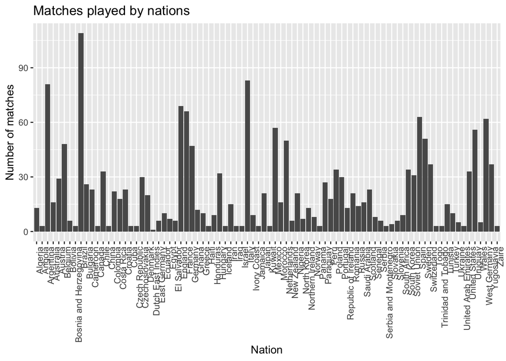

```r
# Select relevant columns and handle missing values
avg_goals <- team_data %>%
  select(match_date, team_name, goals_for, goals_against, goal_differential)

avg_goals$total_goals <- avg_goals$goals_for + avg_goals$goals_against

# Count the number of matches played by each team
num_matches_by_nation <- avg_goals %>%
  group_by(team_name) %>%
  summarize(num_matches_by_nation = n()) %>%
  group_by(team_name) %>%
  summarize(num_matches_by_nation = sum(num_matches_by_nation))



ggplot(num_matches_by_nation, aes(x = team_name, y = num_matches_by_nation)) +
geom_bar(stat = "identity") +
  ylab("Number of matches")+
  xlab("Nation")+
  ggtitle("Matches played by nations")+
  theme(axis.text.x = element_text(angle = 90, hjust = 1))
```

#sum of total goals and average number of goals Now we have to sum the total amount of goals and the calculate the average number of goals by joining the the two dataframes of total goals by nation and number of matches by nation, which can then be visualise

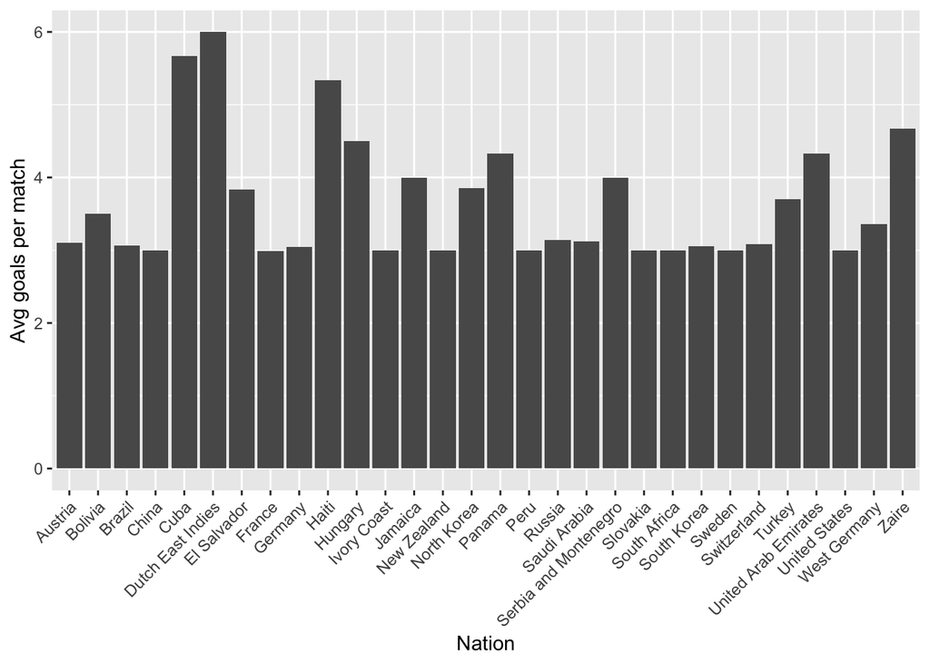

```r
#make data for total_goals
avg_goals$total_goals <- avg_goals$goals_for + avg_goals$goals_against

# Sum the total goals scored by each team
total_goals_by_nation <- avg_goals %>%
group_by(team_name) %>%
summarize(total_goals_by_nation = sum(total_goals))

#Calculate the average number of goals scored per match by each team
avg_goals_per_match_by_nation <- avg_goals %>%
left_join(num_matches_by_nation, by = c("team_name" = "team_name")) %>%
left_join(total_goals_by_nation, by = c("team_name" = "team_name")) %>%
mutate(avg_goals_per_match = total_goals_by_nation / num_matches_by_nation)


avg_goals_per_match_by_nation_selected <- avg_goals_per_match_by_nation %>%
select(team_name, num_matches_by_nation, avg_goals_per_match) %>%
distinct()

#Then, you can sort the data frame by the avg_goals_per_match column using the arrange() function, like this:


top_30_teams_avg_goals <- avg_goals_per_match_by_nation_selected %>%
arrange(desc(avg_goals_per_match)) %>%
head(30)

#Visualize the results
ggplot(top_30_teams_avg_goals, aes(x = team_name, y = avg_goals_per_match)) +
geom_bar(stat = "identity") +
  ylab("Avg goals per match")+
  xlab("Nation")+
theme(axis.text.x = element_text(angle = 45, hjust = 1))
```

#checking if representativ  
Interestingly the countries that historically play the games with the highest goal averages are “Dutch east indies”, “Cuba”, “Haiti” and “Zaire”  
Seeing as these countries aren’t very big football nations my theory is that they have played very few matches in which the score has been really high, we can check this by looking at the same teams but arranging by number of matches instead. we can chech this by making the y value the number of matches played instead og goal average

#arranging for number of games

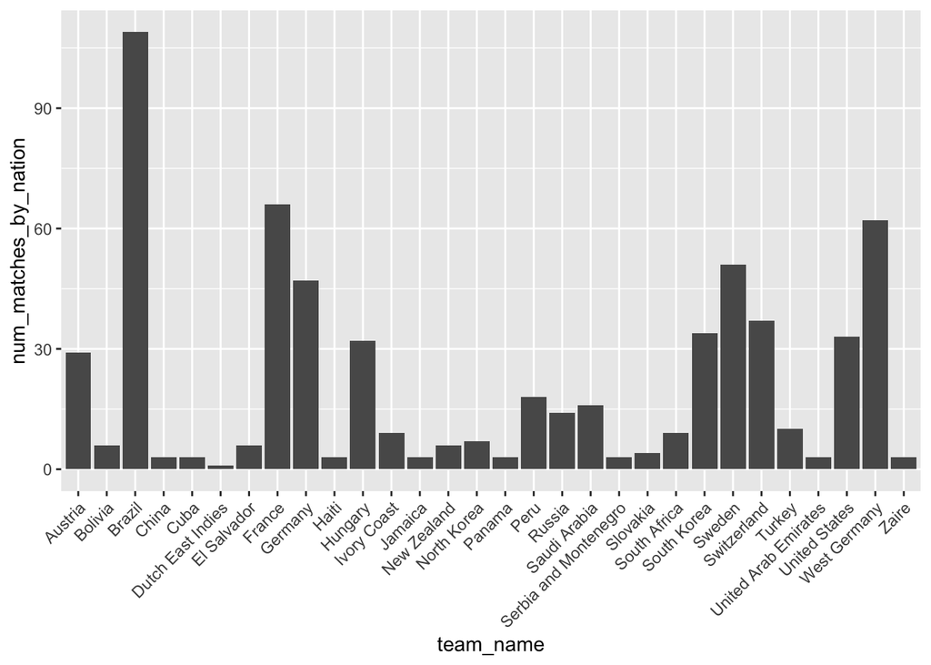

```r
#Visualize the results
ggplot(top_30_teams_avg_goals, aes(x = team_name, y = num_matches_by_nation)) +
geom_bar(stat = "identity") +
theme(axis.text.x = element_text(angle = 45, hjust = 1))
```

here we can se that the “Dutch east indies”, “Cuba”, “Haiti” and “Zaire” have only played a small amount of games during the 90 years of world cup history this means that they usually don’t qualify for the world cup and therefor isn’t very representative of finding teams to watch.

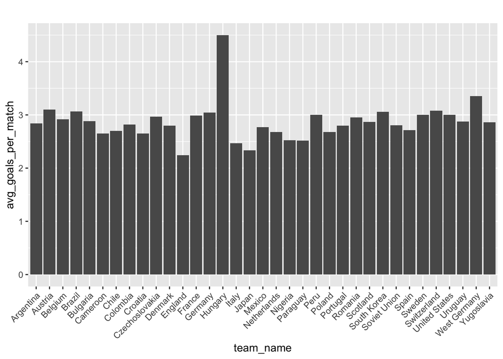

```r
top_35_teams_matches_played <- avg_goals_per_match_by_nation_selected %>%
arrange(desc(num_matches_by_nation)) %>%
head(35)

#Visualize the results
ggplot(top_35_teams_matches_played, aes(x = team_name, y = avg_goals_per_match)) +
geom_bar(stat = "identity") +
theme(axis.text.x = element_text(angle = 45, hjust = 1))+
  labs(title = "")
```

```r
print(top_35_teams_matches_played) %>%
  arrange(desc(avg_goals_per_match))
```

```
## # A tibble: 35 × 3
##    team_name    num_matches_by_nation avg_goals_per_match
##    <chr>                        <int>               <dbl>
##  1 Brazil                         109                3.06
##  2 Italy                           83                2.47
##  3 Argentina                       81                2.84
##  4 England                         69                2.25
##  5 France                          66                2.98
##  6 Spain                           63                2.71
##  7 West Germany                    62                3.35
##  8 Mexico                          57                2.77
##  9 Uruguay                         56                2.88
## 10 Sweden                          51                3
## # … with 25 more rows
```

```
## # A tibble: 35 × 3
##    team_name     num_matches_by_nation avg_goals_per_match
##    <chr>                         <int>               <dbl>
##  1 Hungary                          32                4.5
##  2 West Germany                     62                3.35
##  3 Austria                          29                3.10
##  4 Switzerland                      37                3.08
##  5 Brazil                          109                3.06
##  6 South Korea                      34                3.06
##  7 Germany                          47                3.04
##  8 Sweden                           51                3
##  9 United States                    33                3
## 10 Peru                             18                3
## # … with 25 more rows
```

the plot illustrates that the historically most interesting team of the 35 team with most matches is at the world cup is “Hungary” followed by “West Germany*“,”Austria”, “Switzerland” and “Brazil” and the least interesting team to watch is “England” followed by “Japan”, “Italy” and “Paraguay”.

*West Germany’s national team was fused with east Germany in 1990 to become the German national team